# 市场观察

2017/03/21

## A、指数估值

### (a)动态市盈率、市净率

核心指数成分股近18个月的动态市盈率及动态市净率中位数走势如下图所示：

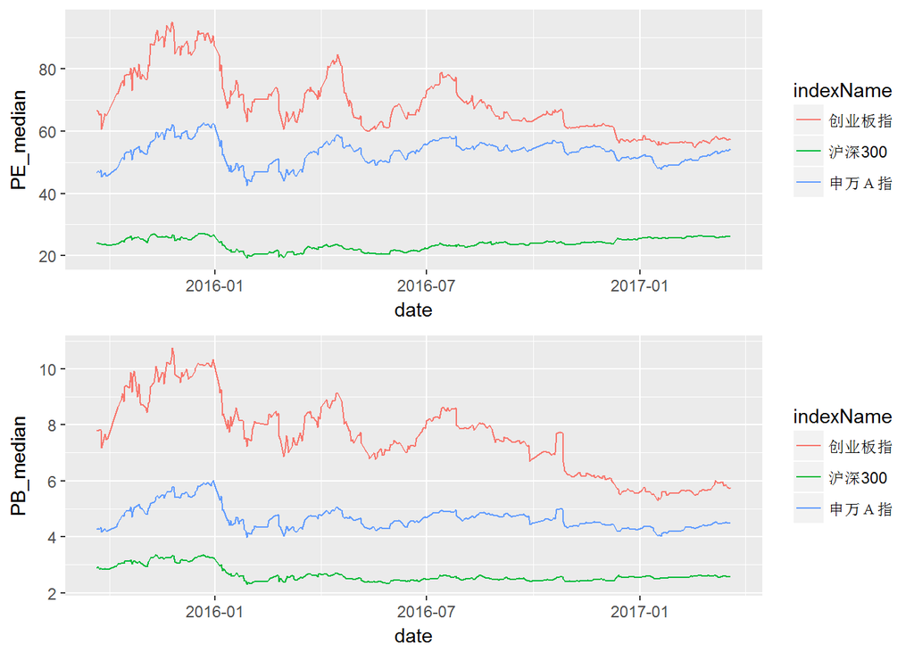

### (b)动态市盈率、市净率百分位

核心指数近18个月的动态市盈率百分位及动态市净率百分位走势如下图所示：

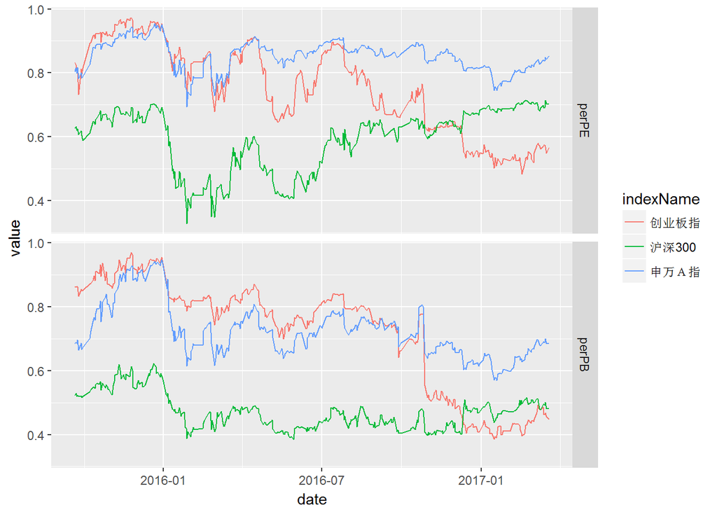

### (c)指数估值概览

| 日期 | 指数代码 | 指数简称 | 动态市盈率 | 市盈率百分位 | 动态市净率 | 市净率百分位 |
| --- | --- | --- | --- | --- | --- | --- |
| 2017-03-20 | EI000979 | 大宗商品 | 54.4 | 94.6% | 2.9 | 68.0% |
| 2017-03-20 | EI801003 | 申万Ａ指 | 54.3 | 85.4% | 4.5 | 68.5% |
| 2017-03-20 | EI000819 | 有色金属 | 61.9 | 84.5% | 3.9 | 78.8% |
| 2017-03-20 | EI000933 | 中证医药 | 41.7 | 77.5% | 4.0 | 11.3% |
| 2017-03-20 | EI399330 | 深证100 | 34.3 | 73.2% | 4.1 | 63.9% |
| 2017-03-20 | EI399005 | 中小板指P | 43.3 | 71.6% | 4.8 | 47.6% |
| 2017-03-20 | EI000300 | 沪深300 | 26.1 | 70.1% | 2.6 | 48.2% |
| 2017-03-20 | EI000905 | 中证500 | 41.1 | 68.8% | 3.2 | 46.2% |
| 2017-03-20 | EI399959 | 军工指数 | 85.1 | 63.0% | 5.5 | 67.9% |
| 2017-03-20 | EI000827 | 中证环保 | 40.9 | 59.3% | 3.2 | 36.9% |
| 2017-03-20 | EI000934 | 中证金融 | 18.5 | 58.0% | 1.9 | 27.7% |
| 2017-03-20 | EI399006 | 创业板指 | 57.5 | 56.7% | 5.7 | 44.8% |
| 2017-03-20 | EI000016 | 上证50 | 17.0 | 54.0% | 1.6 | 16.3% |
| 2017-03-20 | EI000998 | 中证TMT | 44.4 | 48.9% | 4.5 | 42.1% |
| 2017-03-20 | EI000932 | 中证消费 | 30.4 | 35.8% | 3.7 | 16.8% |
| 2017-03-20 | EI000922 | 中证红利 | 16.1 | 35.0% | 1.8 | 33.6% |

### (d)另类估值

我国10年期国债收益率、金银比价、金油比价，2000年以来的历史百分位如下图所示：

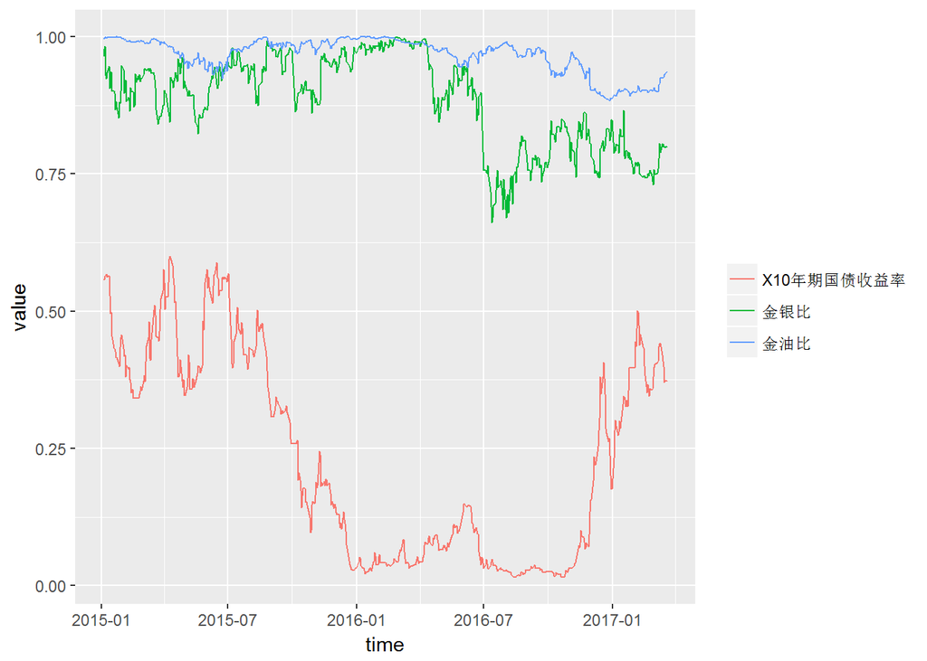

## B、基差

### (a)基差走势

三大股指期货合约基差走势如下图，其中当月合约和次月合约年化基差百分比波动较大，仅展示合约基差百分比，当季合约和次季合约展示基差年化百分比：

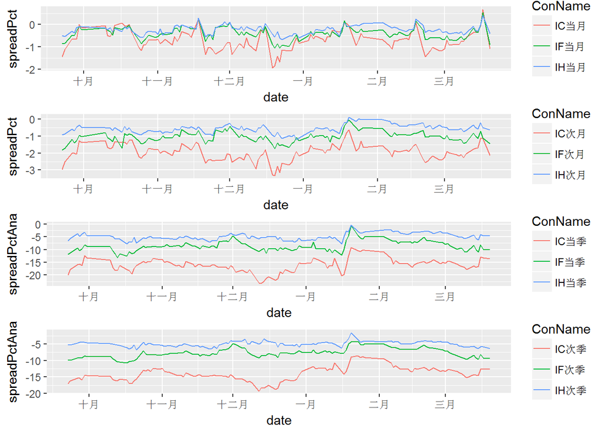

### (b)基差概况

三大股指期货连续合约基差概况如下表，近月合约临近到期日，年化基差百分比数据波动较大：

| 日期 | 合约代码 | 合约收盘价 | 指数收盘价 | 基差 | 基差百分比 | 年化基差百分比 |
| --- | --- | --- | --- | --- | --- | --- |
| 2017-03-20 | IC1704 | 6427.0 | 6498.34 | -71.34 | -1.10% | -13.26% |
| 2017-03-20 | IC1705 | 6359.8 | 6498.34 | -138.54 | -2.13% | -13.69% |
| 2017-03-20 | IC1706 | 6295.2 | 6498.34 | -203.14 | -3.13% | -13.62% |
| 2017-03-20 | IC1709 | 6106.2 | 6498.34 | -392.14 | -6.03% | -12.69% |
| 2017-03-20 | IF1704 | 3417.6 | 3449.61 | -32.01 | -0.93% | -11.11% |
| 2017-03-20 | IF1705 | 3399.2 | 3449.61 | -50.41 | -1.46% | -9.23% |
| 2017-03-20 | IF1706 | 3368.8 | 3449.61 | -80.81 | -2.34% | -10.08% |
| 2017-03-20 | IF1709 | 3294.2 | 3449.61 | -155.41 | -4.51% | -9.40% |
| 2017-03-20 | IH1704 | 2340.2 | 2350.07 | -9.87 | -0.42% | -4.90% |
| 2017-03-20 | IH1705 | 2335.0 | 2350.07 | -15.07 | -0.64% | -3.96% |
| 2017-03-20 | IH1706 | 2324.8 | 2350.07 | -25.27 | -1.08% | -4.54% |
| 2017-03-20 | IH1709 | 2278.0 | 2350.07 | -72.07 | -3.07% | -6.35% |

## C、套利和事件

### (a)复牌股票套利

近两天复牌股票套利情况如下表：

[1] “无复牌股票套利”

### (b)定增基金(provided by han.qian)

截止2017-03-21定增基金数据如下表，明细数据参见钱瀚的模板。

| 代码 | 名称 | 到期日期 | 最新净值 | 昨日收盘价 | 折溢价率 | 整体隐含折价率 | 大盘下跌0.1净值变化 |
| --- | --- | --- | --- | --- | --- | --- | --- |
| 168101.OF | 九泰锐智 | 20200814 | 1.24 | 1.11 | -10.8% | 5.0% | -9.2% |
| 168102.OF | 九泰锐富 | 20210204 | 1.05 | 0.93 | -12.0% | 4.0% | -4.9% |
| 501015.OF | 财通升级 | 20170908 | 1.08 | 1.03 | -4.7% | 3.7% | -8.3% |
| 160518.OF | 博时睿远 | 20171016 | 1.02 | 0.97 | -4.8% | 2.9% | -5.7% |

定增基金近期的净值走势如下图：

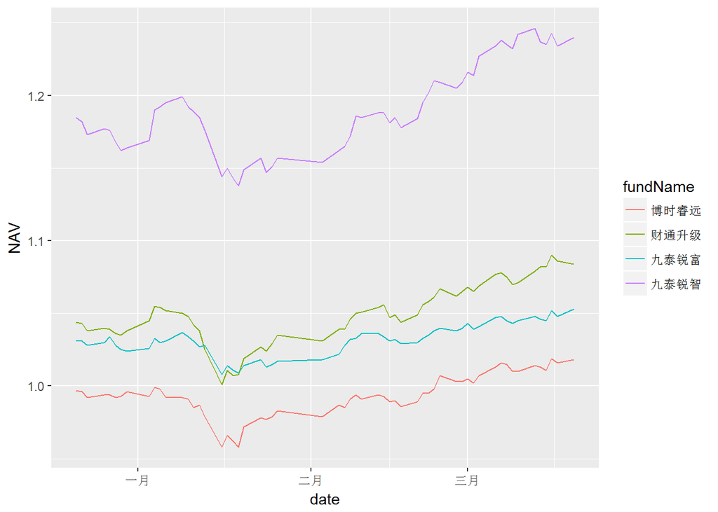

定增基金近期的折溢价率百分比走势如下图：

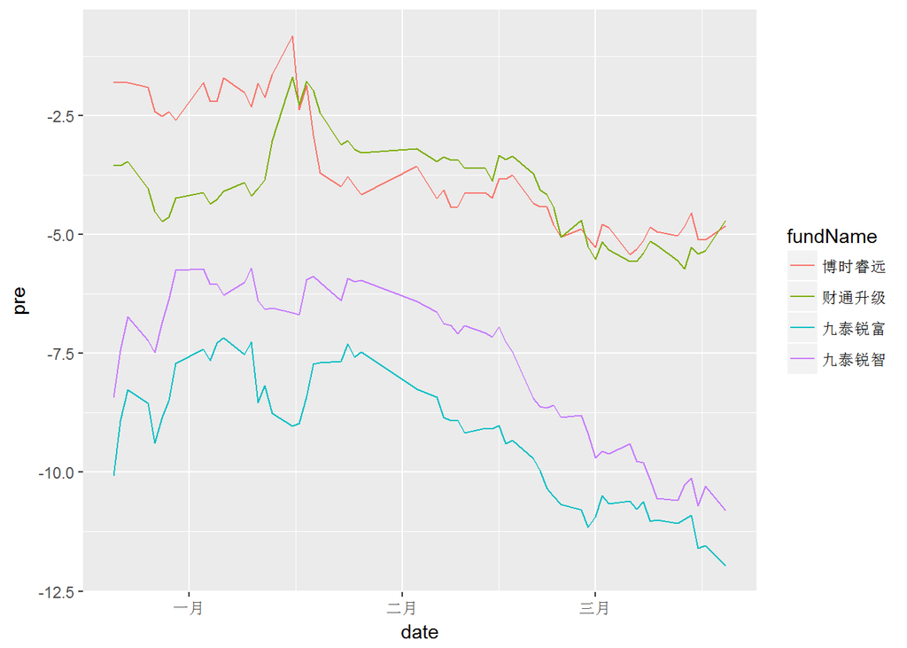

### (c)定增解禁(provided by han.qian)

近十天定增解禁的股票情况如下表。

| 股票代码 | 股票简称 | 跟踪起始日 | 解禁日 | 解禁百分比 | 区间涨跌幅 | 所属行业指数 | 行业指数涨跌幅 |
| --- | --- | --- | --- | --- | --- | --- | --- |
| EQ000591 | 太 阳 能 | 2017-03-06 | 2017-03-20 | 42% | 0.00% | 申万电气设备 | 1.99% |
| EQ600000 | 浦发银行 | 2017-03-06 | 2017-03-20 | 5% | 0.00% | 申万银行 | -1.02% |
| EQ000028 | 国药一致 | 2017-03-07 | 2017-03-21 | 32% | 0.00% | 申万医药生物 | 1.01% |
| EQ300197 | 铁汉生态 | 2017-03-08 | 2017-03-22 | 9% | 0.00% | 申万建筑装饰 | 2.53% |
| EQ600448 | 华纺股份 | 2017-03-08 | 2017-03-22 | 6% | 0.00% | 申万纺织服装 | -0.16% |
| EQ002610 | 爱康科技 | 2017-03-09 | 2017-03-23 | 50% | 0.00% | 申万电气设备 | 1.09% |
| EQ600126 | 杭钢股份 | 2017-03-10 | 2017-03-24 | 10% | 0.00% | 申万钢铁 | 0.19% |
| EQ002176 | 江特电机 | 2017-03-13 | 2017-03-27 | 17% | 0.00% | 申万电气设备 | 1.69% |
| EQ300182 | 捷成股份 | 2017-03-13 | 2017-03-27 | 16% | 0.00% | 申万计算机 | 1.20% |
| EQ600068 | 葛 洲 坝 | 2017-03-13 | 2017-03-27 | 11% | 0.00% | 申万建筑装饰 | 3.42% |
| EQ600303 | 曙光股份 | 2017-03-13 | 2017-03-27 | 8% | 0.00% | 申万汽车 | 0.23% |
| EQ600312 | 平高电气 | 2017-03-13 | 2017-03-27 | 39% | 0.00% | 申万电气设备 | 1.69% |
| EQ601992 | 金隅股份 | 2017-03-13 | 2017-03-27 | 14% | 0.00% | 申万建筑材料 | 3.35% |
| EQ600393 | 粤泰股份 | 2017-03-16 | 2017-03-30 | 65% | 0.00% | 申万房地产 | -1.07% |
| EQ000701 | 厦门信达 | 2017-03-17 | 2017-04-03 | 6% | 0.00% | 申万电子 | -0.56% |
| EQ002217 | 合 力 泰 | 2017-03-17 | 2017-03-31 | 110% | 0.00% | 申万电子 | -0.56% |
| EQ002244 | 滨江集团 | 2017-03-17 | 2017-03-31 | 15% | 0.00% | 申万房地产 | -1.57% |
| EQ002390 | 信邦制药 | 2017-03-17 | 2017-04-03 | 20% | 0.00% | 申万医药生物 | -0.09% |
| EQ300266 | 兴源环境 | 2017-03-17 | 2017-04-04 | 5% | 0.00% | 申万机械设备 | 0.02% |
| EQ600477 | 杭萧钢构 | 2017-03-17 | 2017-04-03 | 19% | 0.00% | 申万建筑装饰 | 0.55% |
| EQ600497 | 驰宏锌锗 | 2017-03-17 | 2017-03-31 | 13% | 0.00% | 申万有色金属 | -0.76% |
| EQ603128 | 华贸物流 | 2017-03-17 | 2017-04-03 | 6% | 0.00% | 申万交通运输 | -0.64% |
| EQ300180 | 华峰超纤 | 2017-03-20 | 2017-04-05 | 26% | 0.00% | 申万化工 | 0.41% |
| EQ002722 | 金轮股份 | 2017-03-21 | 2017-04-06 | 23% | 0.00% | 申万机械设备 | 0.00% |

### (d)中小板业绩预增预测(provided by han.qian)

中小板规定正式财务报告发布的同时需要发布新一期的业绩预报，比如年报中会包含一季报预告的情况。我们假设公司的盈利状况有动量效应，年报预增的公司一季度也会预增，在正式财务报告发布前20个交易日开始埋伏，然后等正式报告发布日卖出。具体研究参见钱瀚前期的研究。需要注意的是这里的收益率仅做展示，仅仅是每日全部入选股票的平均收益率，并没有做成一个事件组合。

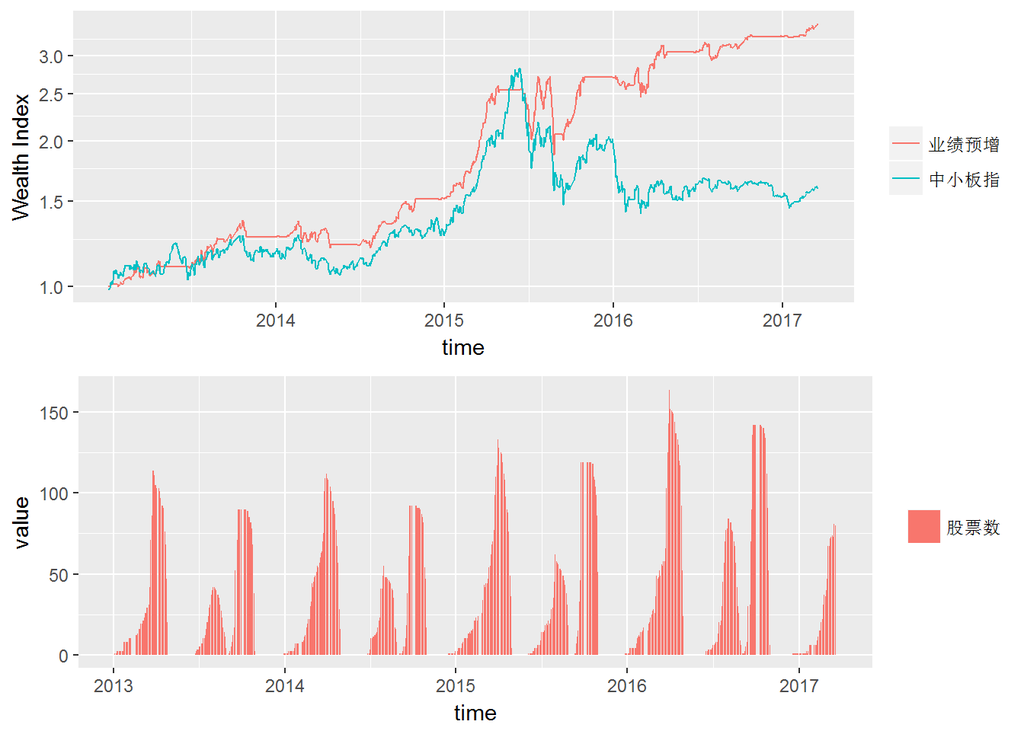

历年收益统计如下表所示。

|  | 业绩预增 | 中小板指 |
| --- | --- | --- |
| 2013-01-04 ~ 2013-12-31 | 26.6% | 17.5% |
| 2014-01-02 ~ 2014-12-31 | 20.1% | 9.7% |
| 2015-01-05 ~ 2015-12-31 | 77.9% | 53.7% |
| 2016-01-04 ~ 2016-12-30 | 22.0% | -22.9% |
| 2017-01-03 ~ 2017-03-20 | 5.8% | 4.5% |
| Cumulative Return | 248.9% | 59.6% |
| Annualized Return | 34.5% | 11.7% |

## D、择时

### (a)等权指数

从历史来看，A股市场存在小盘股效应，市值小的股票长期整体跑赢大市值的股票，美股市场同样存在类似的现象。而目前大部分指数的编制方案都是类似市值加权，为了抛去市值的影响，下面展示几个等权指数，其中中证500等权和沪深300等权是现有的指数，中证全指等权是自己编制的指数。等权指数可以视为一个更好地业绩比较基准。等权指数走势如下图：

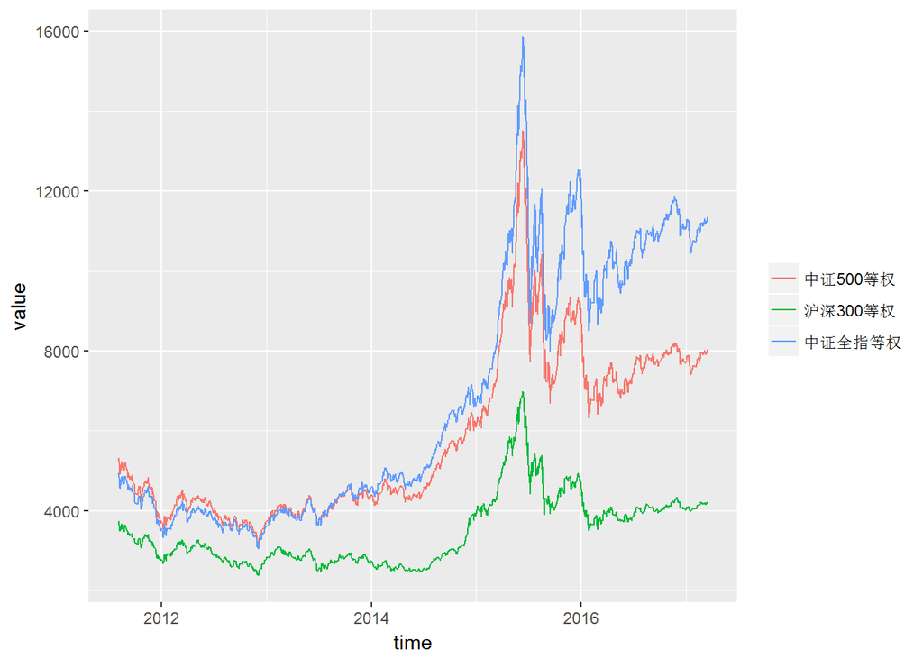

等权指数收益率统计见下表：

|  | 中证500等权 | 沪深300等权 | 中证全指等权 |
| --- | --- | --- | --- |
| 2011-08-02 ~ 2011-12-30 | -29.2% | -25.5% | -27.8% |
| 2012-01-04 ~ 2012-12-31 | -0.0% | 1.5% | 2.2% |
| 2013-01-04 ~ 2013-12-31 | 16.7% | -3.2% | 25.8% |
| 2014-01-02 ~ 2014-12-31 | 40.2% | 43.7% | 46.0% |
| 2015-01-05 ~ 2015-12-31 | 47.6% | 20.1% | 84.4% |
| 2016-01-04 ~ 2016-12-30 | -15.1% | -15.1% | -10.3% |
| 2017-01-03 ~ 2017-03-16 | 4.2% | 4.9% | 2.6% |
| 累计收益率 | 51.2% | 12.7% | 130.1% |
| 年化收益率 | 7.6% | 2.1% | 16.0% |
| 年化波动率 | 28.8% | 26.1% | 29.2% |
| 年化Sharpe值 | 26.5% | 8.2% | 54.7% |
| 最大回撤 | 53.3% | 50.0% | 49.7% |

### (b)大盘均线强弱指数

大盘均线强弱指数在一定程度上可以视为一个反转指标，当大盘均线得分接近8分时，预示市场接近顶部，当大盘均线得分接近0分时，预示市场接近底部。  
大盘均线强弱指数近一年来走势如下图：

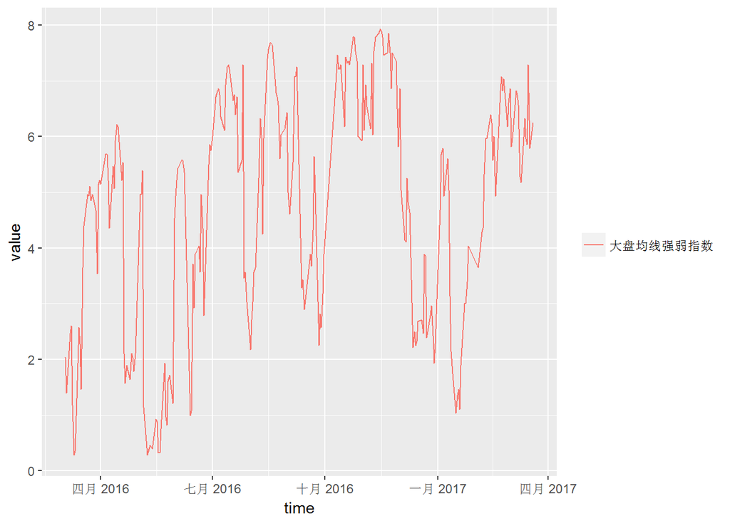

申万一级行业的最新得分见下表：

| 日期 | 指数代码 | 行业 | 最新得分 | 上周得分 |
| --- | --- | --- | --- | --- |
| 2017-03-20 | EI801020 | 采掘 | 8 | 1 |
| 2017-03-20 | EI801030 | 化工 | 8 | 7 |
| 2017-03-20 | EI801050 | 有色金属 | 8 | 8 |
| 2017-03-20 | EI801080 | 电子 | 8 | 8 |
| 2017-03-20 | EI801110 | 家用电器 | 8 | 8 |
| 2017-03-20 | EI801120 | 食品饮料 | 8 | 8 |
| 2017-03-20 | EI801140 | 轻工制造 | 8 | 8 |
| 2017-03-20 | EI801160 | 公用事业 | 8 | 6 |
| 2017-03-20 | EI801210 | 休闲服务 | 8 | 4 |
| 2017-03-20 | EI801230 | 综合 | 8 | 7 |
| 2017-03-20 | EI801710 | 建筑材料 | 8 | 8 |
| 2017-03-20 | EI801720 | 建筑装饰 | 8 | 7 |
| 2017-03-20 | EI801730 | 电气设备 | 8 | 8 |
| 2017-03-20 | EI801770 | 通信 | 8 | 8 |
| 2017-03-20 | EI801890 | 机械设备 | 8 | 8 |
| 2017-03-20 | EI801130 | 纺织服装 | 7 | 5 |
| 2017-03-20 | EI801150 | 医药生物 | 7 | 6 |
| 2017-03-20 | EI801170 | 交通运输 | 6 | 5 |
| 2017-03-20 | EI801880 | 汽车 | 6 | 8 |
| 2017-03-20 | EI801750 | 计算机 | 5 | 5 |
| 2017-03-20 | EI801040 | 钢铁 | 4 | 6 |
| 2017-03-20 | EI801180 | 房地产 | 4 | 8 |
| 2017-03-20 | EI801740 | 国防军工 | 4 | 7 |
| 2017-03-20 | EI801780 | 银行 | 4 | 6 |
| 2017-03-20 | EI801760 | 传媒 | 3 | 2 |
| 2017-03-20 | EI801010 | 农林牧渔 | 2 | 1 |
| 2017-03-20 | EI801200 | 商业贸易 | 2 | 3 |
| 2017-03-20 | EI801790 | 非银金融 | 1 | 1 |

### (c)LLT及均线择时

LLT本质上是一个改进的单均线择时指标，较原始的均线择时延迟更低。  
择时模型和指数本身的净值走势如下图：

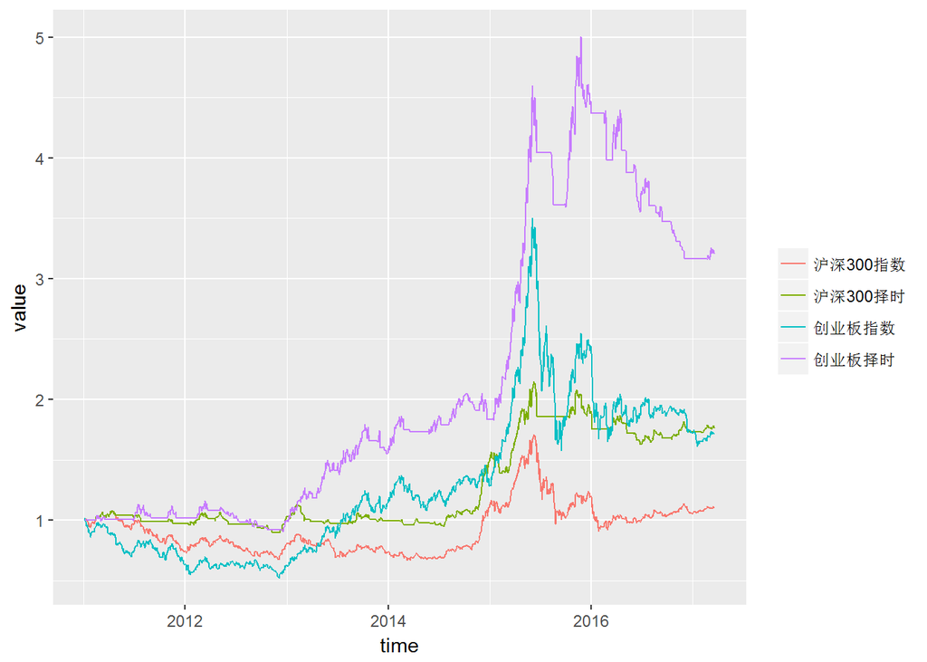

择时模型和指数的收益率统计如下表：

|  | 沪深300指 | 沪深300LLT | 创业板指 | 创业板MA |
| --- | --- | --- | --- | --- |
| 2011-01-04 ~ 2011-12-30 | -25.0% | -2.5% | -35.9% | 1.9% |
| 2012-01-04 ~ 2012-12-31 | 7.6% | 5.4% | -2.1% | -1.7% |
| 2013-01-04 ~ 2013-12-31 | -7.6% | -3.2% | 82.7% | 55.7% |
| 2014-01-02 ~ 2014-12-31 | 51.7% | 52.4% | 12.8% | 17.7% |
| 2015-01-05 ~ 2015-12-31 | 5.6% | 24.3% | 84.4% | 138.1% |
| 2016-01-04 ~ 2016-12-30 | -11.3% | -8.1% | -27.7% | -27.5% |
| 2017-01-03 ~ 2017-03-20 | 4.2% | 2.0% | -0.4% | 1.6% |
| 累计收益率 | 10.3% | 76.9% | 71.7% | 221.7% |
| 年化收益率 | 1.6% | 9.6% | 9.1% | 20.7% |
| 年化波动率 | 24.2% | 15.5% | 32.9% | 22.1% |
| 年化Sharpe值 | 6.6% | 62.0% | 27.7% | 93.4% |
| 最大回撤 | 46.7% | 24.0% | 54.9% | 36.8% |

择时模型最近10个交易日的信号如下表：

| 日期 | 沪深300收盘价 | 沪深300LLT | 沪深300择时信号 | 创业板收盘价 | 创业板MA30 | 创业板择时信号 |
| --- | --- | --- | --- | --- | --- | --- |
| 2017-03-07 | 3453.956 | 3436.749 | hold | 1977.853 | 1904.548 | hold |
| 2017-03-08 | 3448.731 | 3438.831 | hold | 1964.628 | 1908.509 | hold |
| 2017-03-09 | 3426.944 | 3439.915 | hold | 1953.943 | 1912.170 | hold |
| 2017-03-10 | 3427.892 | 3440.248 | hold | 1950.008 | 1914.478 | hold |
| 2017-03-13 | 3458.098 | 3441.559 | hold | 1970.879 | 1917.263 | hold |
| 2017-03-14 | 3456.693 | 3443.724 | hold | 1958.023 | 1920.490 | hold |
| 2017-03-15 | 3463.644 | 3445.944 | hold | 1957.820 | 1923.394 | hold |
| 2017-03-16 | 3481.507 | 3448.843 | hold | 1966.727 | 1926.077 | hold |
| 2017-03-17 | 3445.805 | 3451.001 | hold | 1949.661 | 1928.507 | hold |
| 2017-03-20 | 3449.613 | 3451.996 | hold | 1953.816 | 1930.286 | hold |

### (d)网格交易

在经历了三轮股灾，A股逐步回归正常，在过去的一段时间呈现一个震荡的格局，如果未来没有增量信息，很可能维持震荡。结合股指期货的贴水，前期研究了一下网格交易。网格交易的结果如下图：

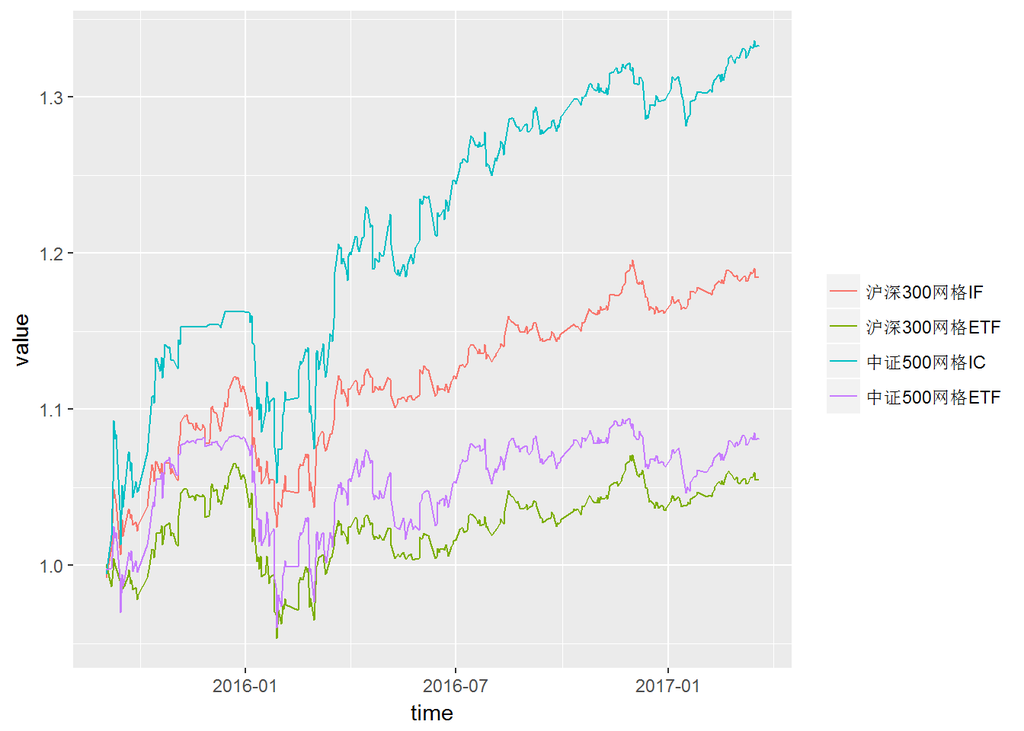

网格交易沪深300股指期货的最新仓位是33.4%，中证500股指期货的最新仓位是36.7%,网格交易的收益统计如下表：

|  | 沪深300指数 | 沪深300网格IF | 沪深300网格ETF | 中证500指数 | 中证500网格IC | 中证500网格ETF |
| --- | --- | --- | --- | --- | --- | --- |
| 2015-09-02 ~ 2015-12-31 | 11.0% | 11.1% | 5.6% | 23.5% | 16.2% | 8.1% |
| 2016-01-04 ~ 2016-12-30 | -11.3% | 4.7% | -1.8% | -17.8% | 11.8% | -1.6% |
| 2017-01-03 ~ 2017-03-20 | 4.2% | 1.8% | 1.8% | 3.7% | 2.6% | 1.6% |
| 累计收益率 | 2.6% | 18.5% | 5.5% | 5.3% | 33.3% | 8.1% |
| 年化收益率 | 1.7% | 11.5% | 3.5% | 3.4% | 20.4% | 5.2% |
| 年化波动率 | 22.0% | 9.2% | 9.0% | 29.7% | 13.6% | 11.6% |
| 年化Sharpe值 | 7.6% | 125.0% | 39.2% | 11.5% | 149.9% | 44.8% |
| 最大回撤 | 26.4% | 8.6% | 10.5% | 33.5% | 9.4% | 11.4% |

## E、选股

### (a)超级小盘股

作为多因子选股的第一部分，有必要从市值因子说起。 下面利用总市值因子，在中证全指的成分股内，选出市值最小的100只股票，这里剔除了ST、新上市、停牌和涨停的股票，100只股票等权配置，每月换仓一次，交易成本千分之三。超级小盘股策略的净值表现如下图。

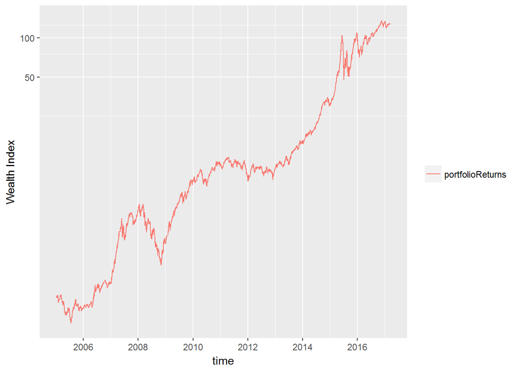

超级小盘股的收益统计如下表：

|  | 超级小盘股 | 沪深300 | 中证500 |
| --- | --- | --- | --- |
| 2005-01-05 ~ 2005-12-30 | -16.7% | -6.0% | -12.8% |
| 2006-01-04 ~ 2006-12-29 | 55.8% | 121.0% | 100.7% |
| 2007-01-04 ~ 2007-12-28 | 265.1% | 161.5% | 186.6% |
| 2008-01-02 ~ 2008-12-31 | -44.5% | -65.9% | -60.8% |
| 2009-01-05 ~ 2009-12-31 | 205.8% | 96.7% | 131.3% |
| 2010-01-04 ~ 2010-12-31 | 32.2% | -12.5% | 10.5% |
| 2011-01-04 ~ 2011-12-30 | -19.4% | -25.0% | -33.8% |
| 2012-01-04 ~ 2012-12-31 | 15.3% | 7.6% | 0.3% |
| 2013-01-04 ~ 2013-12-31 | 63.3% | -7.6% | 16.9% |
| 2014-01-02 ~ 2014-12-31 | 88.8% | 51.7% | 39.0% |
| 2015-01-05 ~ 2015-12-31 | 254.4% | 5.6% | 43.1% |
| 2016-01-04 ~ 2016-12-30 | 21.2% | -11.3% | -17.8% |
| 2017-01-03 ~ 2017-03-16 | -1.3% | 5.2% | 4.5% |
| 累计收益率 | 12810.7% | 254.2% | 565.3% |
| 年化收益率 | 49.0% | 10.9% | 16.8% |
| 年化波动率 | 35.8% | 28.4% | 32.5% |
| 年化Sharpe值 | 136.9% | 38.4% | 51.7% |
| 最大回撤 | 66.3% | 72.3% | 72.4% |

### (b)银行股轮动

银行股轮动是参考集思录的热门贴银行股评级而来的，数据的提取和参数的设置和原贴有一定的差别，所以轮动的效果也会不太一样，不过回测的效果还不错，从现在开始跟踪。2013年以来银行股轮动的结果如下图：

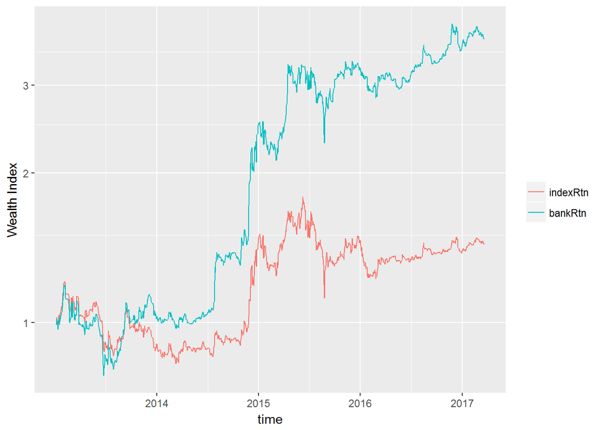

银行股轮动的收益统计如下表：

|  | 申万银行 | 银行股轮动 |
| --- | --- | --- |
| 2013-01-04 ~ 2013-12-31 | -9.2% | 3.0% |
| 2014-01-02 ~ 2014-12-31 | 63.2% | 144.5% |
| 2015-01-05 ~ 2015-12-31 | -1.4% | 29.0% |
| 2016-01-04 ~ 2016-12-30 | -4.9% | 10.5% |
| 2017-01-03 ~ 2017-03-20 | 3.4% | 3.4% |
| 累计收益率 | 43.7% | 271.2% |
| 年化收益率 | 9.0% | 36.5% |
| 年化波动率 | 28.3% | 32.2% |
| 年化Sharpe值 | 31.8% | 113.3% |
| 最大回撤 | 37.4% | 34.2% |

银行股轮动的最新得分如下表：

| 日期 | 代码 | 简称 | PB | 预期ROE | 翻倍期 | 持仓 |
| --- | --- | --- | --- | --- | --- | --- |
| 2017-03-20 | EQ600015 | 华夏银行 | 0.81 | 0.15 | 3.5 | hold |
| 2017-03-20 | EQ601818 | 光大银行 | 0.78 | 0.12 | 3.8 |  |
| 2017-03-20 | EQ601328 | 交通银行 | 0.74 | 0.10 | 4.0 |  |
| 2017-03-20 | EQ601288 | 农业银行 | 0.81 | 0.12 | 4.1 |  |
| 2017-03-20 | EQ601988 | 中国银行 | 0.78 | 0.11 | 4.1 |  |
| 2017-03-20 | EQ601166 | 兴业银行 | 0.90 | 0.14 | 4.3 |  |
| 2017-03-20 | EQ000001 | 平安银行 | 0.79 | 0.11 | 4.4 |  |
| 2017-03-20 | EQ601398 | 工商银行 | 0.86 | 0.13 | 4.5 |  |
| 2017-03-20 | EQ601939 | 建设银行 | 0.94 | 0.14 | 4.9 |  |
| 2017-03-20 | EQ600000 | 浦发银行 | 0.97 | 0.14 | 5.0 |  |
| 2017-03-20 | EQ600016 | 民生银行 | 0.97 | 0.13 | 5.6 |  |
| 2017-03-20 | EQ601169 | 北京银行 | 1.04 | 0.13 | 5.8 |  |
| 2017-03-20 | EQ601998 | 中信银行 | 0.95 | 0.11 | 6.0 |  |
| 2017-03-20 | EQ601009 | 南京银行 | 1.15 | 0.15 | 6.0 |  |
| 2017-03-20 | EQ600036 | 招商银行 | 1.19 | 0.15 | 6.3 |  |
| 2017-03-20 | EQ002142 | 宁波银行 | 1.39 | 0.16 | 6.9 |  |
| 2017-03-20 | EQ600919 | 江苏银行 | 1.41 | 0.13 | 8.6 |  |
| 2017-03-20 | EQ601997 | 贵阳银行 | 1.97 | 0.17 | 8.9 |  |
| 2017-03-20 | EQ601229 | 上海银行 | 1.41 | 0.12 | 9.2 |  |
| 2017-03-20 | EQ600926 | 杭州银行 | 1.70 | 0.10 | 12.4 |  |
| 2017-03-20 | EQ601128 | 常熟银行 | 2.91 | 0.10 | 18.0 |  |
| 2017-03-20 | EQ600908 | 无锡银行 | 2.88 | 0.10 | 18.4 |  |
| 2017-03-20 | EQ603323 | 吴江银行 | 2.91 | 0.08 | 22.8 |  |
| 2017-03-20 | EQ002807 | 江阴银行 | 4.07 | 0.09 | 25.6 |  |